# Data Assembly: 2017 NHTS (School Trips) - Join with 2009

Aanchal Chopra

2024-04-01

# Data Assembly notes

## Constructing the Sample

Data for this analysis is drawn from the 2017 National Household Travel Survey (https://nhts.ornl.gov/).

#### Criteria for inclusion in sample

**Data**

- Data not missing for any outcome or predictor variables

**Trip (to ensure one trip per child, and only school trips):**

- Trip distance is shorter than 2km/1.25 miles
- Trip ends at school
- Trip is not by transit, motorcycle, or an unspecified mode (these are rare and I assume they are not available to the remaining children)
- Child does not use a school bus for the trip to *or* from school (assume the remaining students are ineligible for school bus service)
- Survey does not indicate that the child drove to school unaccompanied (assume these are survey coding errors)
- Survey does not indicate the child traveled to school by car with “only siblings” unless the child has a sibling who is a driver.
- Trip does not begin AND end at school
- Trip ends before 10am
- This is the first qualifying trip of the day

**Traveler**

- Traveler is between 8 and 13

#### Assembling Multi-stage trips

If the trip ending at school begins with a transfer from another mode, the prior trip is included as part of this trip, and trip characteristics are determined as follows:

- Matched with the characteristics of the longest-distance segment of the trip:
  - Mode
  - Presence of others *Summed across all segments:
  - Trip distance *Taken from the first segment of the trip:
  - Population density at trip origin
  - All individual- and household-level variables
- Taken from last segment of trip
  - Population density at trip destination

## Defining the variables

#### Availability variables

**‘av_car’, ‘av_walk’, and ‘av_bike’** indicate the trips for which travel by car, walking, or bike is available. We are assuming that these three modes are available for all children in the sample (even if there is not car in the household, since some children in the sample in zero-vehicle households *do* travel by car) so this value is set to one for all cases.

The following variables indicate the availability of independence alternatives:

- alone_avail: TRUE/1 for all trips
- with_mom_dad_avail: True if there is both a female and a male adult in the household.
- with_mom_avail: True if there is a female adult in the household
- with_dad_avail: True if there is a male adult in the household
- with_non_hh_avail: True for all trips
- with_sib_avail: True if there are any other children in the household
- with_adult_avail: True for all trips

#### Predictor variables

**Household-level variables**:

- income_k: NHTS codes income in one of 11 income categories. We convert this to a continuous variable by assigning households in each category the mid-point value of that category. The highest income category is for incomes greater than $200,000 per year. We assign an income of $250,000 to that category. log_income_k is the natural log of income_k.
- veh_per_driver: We divide the number of household vehicles by the number of household drivers. We assign a value of zero to households with zero drivers
- n_adults: The number of household adults
- has_mom: A binary variable indicating whether there is a female adult in the household
- has_dad: A binary variable indicating whether there is a male adult in the household
- non_work_mom: A binary variable indicating whether there is a female adult in the household who is not a worker
- non_work_dad: A binary variable indicating whether there is a male adult in the household who is not a worker

**Individual-level variables**:

- age: The child’s age *female: A binary variable indicating whether the child is female
- has_lil_sib: A binary variable indicating whether there are any younger children in the household (includes children who are the same age as the respondent)
- has_big_sib: A binary variable indicating whether there are any older children in the household

**Trip-level variables**:

# Data Assembly

#### 1 Load NHTS trip and person files

```r
library(tidyverse)
library(knitr)
library(tidyr)
library(dplyr)
library(here)
library(kableExtra)
library(magrittr)
library(downloader)
library(naniar)
library(ggplot2)

trips <- here("nhts",
              "data2017",
              "trippub.csv") |>
  read_csv(show_col_types = FALSE)


people <- here("nhts",
               "data2017",
               "perpub.csv") |>
  read_csv(show_col_types = FALSE) |>
  mutate(person_hh = paste(PERSONID, HOUSEID, sep = "-"))
```

#### 2 Assemble ages and genders of household members

```r
hh_ages <- people |>
  select(HOUSEID, PERSONID, R_AGE) |>
  pivot_wider(names_from = PERSONID,
              names_prefix = "age_",
              values_from = R_AGE)

hh_genders <- people %>%
  select(HOUSEID, PERSONID, R_SEX_IMP) |>
  pivot_wider(names_from = PERSONID,
              names_prefix = "gender_",
              values_from = R_SEX_IMP)
```

#### 3 Assemble relationships of all individuals

```r
relationships <- people |>
  mutate(adult = R_AGE > 17,
         mom = R_AGE > 17 & R_SEX_IMP == "02",
         dad = R_AGE > 17 & R_SEX_IMP != "02",
         kid_age = ifelse(R_AGE < 18, R_AGE, -2),
         R_AGE = ifelse(R_AGE < 0, 999, R_AGE),
         non_worker_mom = R_AGE > 17 & WORKER != "01" & R_SEX_IMP == "02",
         non_worker_dad = R_AGE > 17 & WORKER != "01" & R_SEX_IMP != "02",
         driver_mom = R_AGE > 17 & DRIVER == "01" & R_SEX_IMP == "02",
         driver_dad = R_AGE > 17 & DRIVER == "01" & R_SEX_IMP != "02",
         driver_sib = R_AGE < 18 & DRIVER == "01") |>
  group_by(HOUSEID) |>
  mutate(n_adults = sum(adult),
         has_mom = sum(mom) > 0,
         has_dad = sum(dad) > 0,
         driver_mom = sum(driver_mom) > 0,
         driver_dad = sum(driver_dad) > 0,
         driver_sib = sum(driver_sib) > 0,
         num_records = n(),
         non_work_mom = sum(non_worker_mom) > 0,
         non_work_dad = sum(non_worker_dad) > 0) |>
  mutate(youngest_kid = ifelse(num_records > HHSIZE, 1, min(R_AGE)),
         oldest_kid = max(kid_age),
         n_children = HHSIZE - n_adults) |>
  mutate(has_big_sib = n_children > 1 & R_AGE != oldest_kid) |>
  mutate(has_lil_sib = n_children > 1 & (R_AGE != youngest_kid | !has_big_sib)) |>
  mutate(person_hh = paste(PERSONID, HOUSEID, sep = "-")) |>
  ungroup() |>
  select(person_hh,
         R_AGE,
         R_SEX_IMP,
         WORKER,
         has_lil_sib,
         has_big_sib,
         n_adults,
         has_mom,
         has_dad,
         non_work_mom,
         non_work_dad,
         driver_mom,
         driver_dad,
         driver_sib)
```

#### 4 Assemble trips and school trips

```r
school_trips <- trips |>
  mutate(include_trip = (WHYTO == "08" &
                           WHYFROM != "08" &
                           R_AGE > 7 &
                           R_AGE < 14 &
                           as.numeric(ENDTIME) < 1000 &
                           TRPMILES > 0)) |>
  mutate(WHYTO = ifelse(WHYTO == "07", "transfer", WHYTO),
         WHYFROM = ifelse(WHYFROM == "07", "transfer", WHYFROM),
         mode = case_when(TRPTRANS == "10" ~ 1, # school bus
                          TRPTRANS == "03" ~ 7, # car
                          TRPTRANS == "04" ~ 7,
                          TRPTRANS == "05" ~ 7,
                          TRPTRANS == "06" ~ 7,
                          TRPTRANS == "01" ~ 8, # walk
                          TRPTRANS == "02" ~ 9, # bike
                          TRPTRANS == "11" ~ 2, # transit
                          TRPTRANS == "12" ~ 2,
                          TRPTRANS == "13" ~ 2,
                          TRPTRANS == "14" ~ 2,
                          TRPTRANS == "15" ~ 2,
                          TRPTRANS == "16" ~ 2,
                          TRPTRANS == "08" ~ 3, # motorcycle
                          TRPTRANS == "97" ~ 4, # unspecified
                          TRUE ~ 5)) |>
  mutate(TDTRPNUM = ifelse(WHYFROM == "transfer",
                           paste0("0", as.numeric(TDTRPNUM) - 1),
                           TDTRPNUM)) |>
  mutate(trip_person_hh = paste(TDTRPNUM, PERSONID, HOUSEID, sep = "-")) |>
  mutate(person_hh = paste(PERSONID, HOUSEID, sep = "-")) |>
  group_by(trip_person_hh) |>
  mutate(longest_seg = TRPMILES == max(TRPMILES)) |>
  mutate(mode = ifelse(longest_seg, mode, 999)) |>
  mutate(NUMONTRP = ifelse(longest_seg, NUMONTRP, -1),
         NONHHCNT = ifelse(longest_seg, NONHHCNT, -1),
         ONTD_P1 = ifelse(longest_seg, as.numeric(ONTD_P1), -1),
         ONTD_P2 = ifelse(longest_seg, as.numeric(ONTD_P2), -1),
         ONTD_P3 = ifelse(longest_seg, as.numeric(ONTD_P3), -1),
         ONTD_P4 = ifelse(longest_seg, as.numeric(ONTD_P4), -1),
         ONTD_P5 = ifelse(longest_seg, as.numeric(ONTD_P5), -1),
         ONTD_P6 = ifelse(longest_seg, as.numeric(ONTD_P6), -1),
         ONTD_P7 = ifelse(longest_seg, as.numeric(ONTD_P7), -1),
         ONTD_P8 = ifelse(longest_seg, as.numeric(ONTD_P8), -1),
         ONTD_P9 = ifelse(longest_seg, as.numeric(ONTD_P9), -1),
         ONTD_P10 = ifelse(longest_seg, as.numeric(ONTD_P10), -1),
         ONTD_P11 = ifelse(longest_seg, as.numeric(ONTD_P11), -1),
         ONTD_P12 = ifelse(longest_seg, as.numeric(ONTD_P12), -1),
         ONTD_P13 = ifelse(longest_seg, as.numeric(ONTD_P13), -1)) |>
  summarise(person_hh = first(person_hh),
            HOUSEID = first(HOUSEID),
            WHYFROM = first(WHYFROM),
            WHYTO = last(WHYTO),
            mode = min(mode),
            NUMONTRP = max(NUMONTRP),
            NONHHCNT = max(NONHHCNT),
            R_AGE = first(R_AGE),
            ENDTIME = last(ENDTIME),
            include_trip = max(include_trip),
            ONTD_P1 = max(ONTD_P1),
            ONTD_P2 = max(ONTD_P2),
            ONTD_P3 = max(ONTD_P3),
            ONTD_P4 = max(ONTD_P4),
            ONTD_P5 = max(ONTD_P5),
            ONTD_P6 = max(ONTD_P6),
            ONTD_P7 = max(ONTD_P7),
            ONTD_P8 = max(ONTD_P8),
            ONTD_P9 = max(ONTD_P9),
            ONTD_P10 = max(ONTD_P10),
            ONTD_P11 = max(ONTD_P11),
            ONTD_P12 = max(ONTD_P12),
            ONTD_P13 = max(ONTD_P13),
            HHVEHCNT = first(HHVEHCNT),
            DRVRCNT = first(DRVRCNT),
            HHFAMINC = first(HHFAMINC),
            R_SEX_IMP = first(R_SEX_IMP),
            TRPMILES = sum(TRPMILES),
            DBPPOPDN = last(DBPPOPDN)) |> ## Change density to household block
  group_by(person_hh) |>
  mutate(can_drive = DRVRCNT > 0 & HHVEHCNT > 0,
         can_sch_bus = sum(mode == 1) > 0) |>
  ungroup() |>
  filter(TRPMILES < 1.25) |>
  filter(include_trip > 0) |>
  filter(!duplicated(person_hh)) |>
  filter(mode > 6,
         !can_sch_bus) |>
  left_join(hh_ages) |>
  left_join(hh_genders) |>
  mutate(alone = NUMONTRP == 1,
         with_mom =
           (ONTD_P1 == 1 & age_01 > 17 & gender_01 == "02") |
           (ONTD_P2 == 1 & age_02 > 17 & gender_02 == "02") |
           (ONTD_P3 == 1 & age_03 > 17 & gender_03 == "02") |
           (ONTD_P4 == 1 & age_04 > 17 & gender_04 == "02") |
           (ONTD_P5 == 1 & age_05 > 17 & gender_05 == "02") |
           (ONTD_P6 == 1 & age_06 > 17 & gender_06 == "02") |
           (ONTD_P7 == 1 & age_07 > 17 & gender_07 == "02") |
           (ONTD_P8 == 1 & age_08 > 17 & gender_08 == "02") |
           (ONTD_P9 == 1 & age_09 > 17 & gender_09 == "02") |
           (ONTD_P10 == 1 & age_10 > 17 & gender_10 == "02") |
           (ONTD_P11 == 1 & age_11 > 17 & gender_11 == "02") |
           (ONTD_P12 == 1 & age_12 > 17 & gender_12 == "02") |
           (ONTD_P13 == 1 & age_13 > 17 & gender_13 == "02"),
         with_dad =
           (ONTD_P1 == 1 & age_01 > 17 & gender_01 != "02") |
           (ONTD_P2 == 1 & age_02 > 17 & gender_02 != "02") |
           (ONTD_P3 == 1 & age_03 > 17 & gender_03 != "02") |
           (ONTD_P4 == 1 & age_04 > 17 & gender_04 != "02") |
           (ONTD_P5 == 1 & age_05 > 17 & gender_05 != "02") |
           (ONTD_P6 == 1 & age_06 > 17 & gender_06 != "02") |
           (ONTD_P7 == 1 & age_07 > 17 & gender_07 != "02") |
           (ONTD_P8 == 1 & age_08 > 17 & gender_08 != "02") |
           (ONTD_P9 == 1 & age_09 > 17 & gender_09 != "02") |
           (ONTD_P10 == 1 & age_10 > 17 & gender_10 != "02") |
           (ONTD_P11 == 1 & age_11 > 17 & gender_11 != "02") |
           (ONTD_P12 == 1 & age_12 > 17 & gender_12 != "02") |
           (ONTD_P13 == 1 & age_13 > 17 & gender_13 != "02"),
         hh_only = NUMONTRP == NONHHCNT+1) |>
  left_join(relationships) |>
  mutate(independence = case_when(with_mom & with_dad ~ 21,
                                  with_mom ~ 22,
                                  with_dad ~ 23,
                                  alone ~ 10,
                                  NONHHCNT == 0 ~ 30,
                                  TRUE ~ 24)) |>
  mutate(ind_3 = ifelse(independence > 20 & independence < 30,
                        20, independence)) |>
  mutate(ind_3_alt = case_when(independence > 10 & independence < 24 ~ 20,
                               independence == 24 ~ 30,
                               TRUE ~ independence)) |>
  filter(!(mode == 7 & independence == 10),
         !(mode == 7 & independence == 30 & !driver_sib)) |>
  mutate(mode_ind = mode * 100 + independence,
         mode_ind_3 = mode * 100 + ind_3,
         mode_ind_3_alt = mode * 100 + ind_3_alt) |>
  mutate(veh_per_driver = ifelse(DRVRCNT > 0, HHVEHCNT/DRVRCNT, 0)) |>
  mutate(income_k = case_when(HHFAMINC == "01" ~ 5,
                              HHFAMINC == "02" ~ 12.5,
                              HHFAMINC == "03" ~ 20,
                              HHFAMINC == "04" ~ 30,
                              HHFAMINC == "05" ~ 42.5,
                              HHFAMINC == "06" ~ 62.5,
                              HHFAMINC == "07" ~ 87.5,
                              HHFAMINC == "08" ~ 112.5,
                              HHFAMINC == "09" ~ 137.5,
                              HHFAMINC == "10" ~ 175,
                              HHFAMINC == "11" ~ 250,
                              TRUE ~ -9)) |>
  filter(income_k > 0) |>
  mutate(max_od_dens = DBPPOPDN) |>
  filter(max_od_dens > 0) |>
  rename(age = R_AGE) |>
  mutate(female = as.numeric(R_SEX_IMP == "02"),
         has_mom = as.numeric(has_mom),
         has_dad = as.numeric(has_dad),
         non_work_mom = as.numeric(non_work_mom),
         non_work_dad = as.numeric(non_work_dad),
         has_lil_sib = as.numeric(has_lil_sib),
         has_big_sib = as.numeric(has_big_sib),
         distance = TRPMILES * 1.609,
         density = max_od_dens / 2.59) |>
  mutate(with_mom_avail = ifelse(has_mom == 1, 1, 0),
         with_dad_avail = ifelse(has_dad ==1, 1, 0),
         with_mom_dad_avail = ifelse(has_mom + has_dad == 2, 1, 0),
         with_sib_avail = ifelse(has_lil_sib + has_big_sib > 0, 1, 0)) |>
  mutate(log_income_k = log(income_k),
         log_distance = log(distance),
         log_density = log(density),
         av_car = 1,
         av_walk = 1,
         av_bike = 1,
         alone_avail = 1,
         with_non_hh_avail = 1,
         with_adult_avail = 1) |>
  select(mode,
         independence,
         ind_3,
         ind_3_alt,
         mode_ind,
         mode_ind_3,
         mode_ind_3_alt,
         income_k,
         log_income_k,
         veh_per_driver,
         n_adults,
         non_work_mom,
         non_work_dad,
         age,
         female,
         has_lil_sib,
         has_big_sib,
         distance,
         log_distance,
         density,
         log_density,
         av_car,
         av_walk,
         av_bike,
         alone_avail,
         with_mom_dad_avail,
         with_mom_avail,
         with_dad_avail,
         with_non_hh_avail,
         with_sib_avail,
         with_adult_avail)
```

#### 5 Add column for year

```r
school_trips <- school_trips |>
  mutate(year = 2017)
```

# Summary Statistics

#### Number of transfers

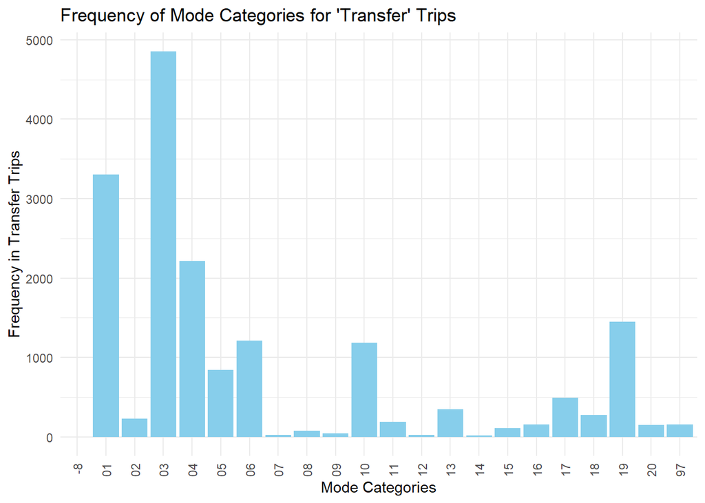

```r
transfers <- trips |>
  select(WHYTO, WHYFROM,TRPTRANS) |>
  filter (WHYTO == "07" | WHYFROM == "07")

transfers_freq <- transfers |>
  count(TRPTRANS)

ggplot(transfers_freq, aes(x = TRPTRANS, y = n)) +
  geom_bar(stat = "identity", fill = "skyblue") +
  labs(x = "Mode Categories", y = "Frequency in Transfer Trips", title = "Frequency of Mode Categories for 'Transfer' Trips") +
  theme_minimal() +
  theme(axis.text.x = element_text(angle = 90, vjust = 0.5, hjust=1))
```

#### Sample Size

Sample size

| Unit | Sample |
| --- | --- |
| Households | 1658 |
| Children | 1658 |
| Trips | 1658 |

#### Outcome 1: Full Independence Variable

Number of trips in sample by mode and (full) independence

Car

Bike

Walk

Total

Alone

0

67

155

222

With mom and dad

21

2

11

34

With mom

670

16

115

801

With dad

308

6

46

360

With non-household

58

8

68

134

With siblings

7

15

85

107

Total

1064

114

480

1658

Share of trips in sample by mode and (full) independence

Car

Bike

Walk

Total

Alone

0%

4%

9.3%

13.4%

With mom and dad

1.3%

0.1%

0.7%

2.1%

With mom

40.4%

1%

6.9%

48.3%

With dad

18.6%

0.4%

2.8%

21.7%

With non-household

3.5%

0.5%

4.1%

8.1%

With siblings

0.4%

0.9%

5.1%

6.5%

Total

64.2%

6.9%

29%

100%

#### Outcome 2: Simplified Independence Variable

Number of trips in sample by mode and (simplified) independence

Car

Bike

Walk

Total

Alone

0

67

155

222

With adults

1057

32

240

1329

With kids

7

15

85

107

Total

1064

114

480

1658

Share of trips in sample by mode and (simplified) independence

Car

Bike

Walk

Total

Alone

0%

4%

9.3%

13.4%

With adults

63.8%

1.9%

14.5%

80.2%

With kids

0.4%

0.9%

5.1%

6.5%

Total

64.2%

6.9%

29%

100%

#### Outcome 3: Alternative Simplified Independence Variable

Number of trips in sample by mode and (alternative simplified) independence

Car

Bike

Walk

Total

Alone

0

67

155

222

With adults

999

24

172

1195

With kids

65

23

153

241

Total

1064

114

480

1658

Share of trips in sample by mode and (alternative simplified) independence

Car

Bike

Walk

Total

Alone

0%

4%

9.3%

13.4%

With adults

60.3%

1.4%

10.4%

72.1%

With kids

3.9%

1.4%

9.2%

14.5%

Total

64.2%

6.9%

29%

100%

#### Choice Availability

Prevalence and availability of full independence choices

| Full independence variable | Percent selected | Percent available |
| --- | --- | --- |
| Alone | 13% | 100% |
| With mom and dad | 2% | 83% |
| With mom | 48% | 97% |
| With dad | 22% | 86% |
| With non-household | 8% | 100% |
| With siblings | 6% | 81% |

#### Predictors

Descriptive statistics of predictor variables

| Predictor | Mean | Standard Deviation |
| --- | --- | --- |
| age | 10.158 | 1.644 |
| alone_avail | 1.000 | 0.000 |
| density | 2024.722 | 1892.417 |
| distance | 1.099 | 0.485 |
| female | 0.479 | NA |
| has_big_sib | 0.457 | NA |
| has_lil_sib | 0.475 | NA |
| income_k | 97.603 | 70.048 |
| log_density | 7.107 | 1.227 |
| log_distance | -0.040 | 0.594 |
| log_income_k | 4.253 | 0.921 |
| n_adults | 2.044 | 0.696 |
| non_work_dad | 0.110 | NA |
| non_work_mom | 0.345 | NA |
| veh_per_driver | 1.090 | 0.510 |
| year | 2017.000 | 0.000 |